# Titanic Project

#### Goal: Try to predict whether a Titanic passenger will survive or die, based on their description.

Akshat Chopra - 03/20/2022

#### Steps done:

1. Import data and drop non-key variables
2. Fill in missing values
3. Data Visualizations for variables with high correlation to Survival
4. Outlier Analysis
5. Applying Different Models to our Data
6. Choosing Best Model and Creating Submission File

```python
import numpy as np
import pandas as pd
import matplotlib.pyplot as plt
import sklearn
import seaborn as sb

from pylab import rcParams
from sklearn.linear_model import LinearRegression
from sklearn.linear_model import LogisticRegression
from sklearn.model_selection import train_test_split

from sklearn import metrics
from sklearn.metrics import classification_report, confusion_matrix
from sklearn.metrics import precision_score, recall_score, accuracy_score
from sklearn.cluster import DBSCAN

from sklearn.naive_bayes import BernoulliNB, GaussianNB, MultinomialNB
from sklearn.ensemble import RandomForestClassifier
from sklearn.tree import DecisionTreeClassifier
from sklearn.linear_model import Perceptron
from sklearn import neighbors
from sklearn.neighbors import KNeighborsClassifier
```

```python
%matplotlib inline
rcParams['figure.figsize'] = 10,8
sb.set_style('whitegrid')
```

## Part 1 - Importing Data and dropping non-key variables

Let's begin by importing our training and testing data, renaming our columns, and inspecting the data.

```python
address_train = '/Users/akshatchopra/Desktop/Python Datasets/titanic/train.csv'
train_set = pd.read_csv(address_train)
train_set.columns = ['PassId', 'Survived', 'Ticket Class', 'Name', 'Gender', 'Age', 'Siblings Spouses', 'Parents Children', 'Ticket Num', 'Fare', 'Cabin Num', 'Port Embarked']

address_test = '/Users/akshatchopra/Desktop/Python Datasets/titanic/test.csv'
test_set = pd.read_csv(address_test)
test_set.columns = ['PassId', 'Ticket Class', 'Name', 'Gender', 'Age', 'Siblings Spouses', 'Parents Children', 'Ticket Num', 'Fare', 'Cabin Num', 'Port Embarked']

train_set.head()
# Shows first five rows of the dataset
```

|  | PassId | Survived | Ticket Class | Name | Gender | Age | Siblings Spouses | Parents Children | Ticket Num | Fare | Cabin Num | Port Embarked |
| --- | --- | --- | --- | --- | --- | --- | --- | --- | --- | --- | --- | --- |
| 0 | 1 | 0 | 3 | Braund, Mr. Owen Harris | male | 22.0 | 1 | 0 | A/5 21171 | 7.2500 | NaN | S |
| 1 | 2 | 1 | 1 | Cumings, Mrs. John Bradley (Florence Briggs Th... | female | 38.0 | 1 | 0 | PC 17599 | 71.2833 | C85 | C |
| 2 | 3 | 1 | 3 | Heikkinen, Miss. Laina | female | 26.0 | 0 | 0 | STON/O2. 3101282 | 7.9250 | NaN | S |
| 3 | 4 | 1 | 1 | Futrelle, Mrs. Jacques Heath (Lily May Peel) | female | 35.0 | 1 | 0 | 113803 | 53.1000 | C123 | S |
| 4 | 5 | 0 | 3 | Allen, Mr. William Henry | male | 35.0 | 0 | 0 | 373450 | 8.0500 | NaN | S |

```python
test_set.head()
```

|  | PassId | Ticket Class | Name | Gender | Age | Siblings Spouses | Parents Children | Ticket Num | Fare | Cabin Num | Port Embarked |
| --- | --- | --- | --- | --- | --- | --- | --- | --- | --- | --- | --- |
| 0 | 892 | 3 | Kelly, Mr. James | male | 34.5 | 0 | 0 | 330911 | 7.8292 | NaN | Q |
| 1 | 893 | 3 | Wilkes, Mrs. James (Ellen Needs) | female | 47.0 | 1 | 0 | 363272 | 7.0000 | NaN | S |
| 2 | 894 | 2 | Myles, Mr. Thomas Francis | male | 62.0 | 0 | 0 | 240276 | 9.6875 | NaN | Q |
| 3 | 895 | 3 | Wirz, Mr. Albert | male | 27.0 | 0 | 0 | 315154 | 8.6625 | NaN | S |
| 4 | 896 | 3 | Hirvonen, Mrs. Alexander (Helga E Lindqvist) | female | 22.0 | 1 | 1 | 3101298 | 12.2875 | NaN | S |

```python
print(train_set.shape)
print(test_set.shape)

# Rows and columns of our dataset
```

```
(891, 12)
(418, 11)
```

```python
train_set.describe()

# Gives summary statistics of our numerical variables
```

|  | PassId | Survived | Ticket Class | Age | Siblings Spouses | Parents Children | Fare |
| --- | --- | --- | --- | --- | --- | --- | --- |
| count | 891.000000 | 891.000000 | 891.000000 | 714.000000 | 891.000000 | 891.000000 | 891.000000 |
| mean | 446.000000 | 0.383838 | 2.308642 | 29.699118 | 0.523008 | 0.381594 | 32.204208 |
| std | 257.353842 | 0.486592 | 0.836071 | 14.526497 | 1.102743 | 0.806057 | 49.693429 |
| min | 1.000000 | 0.000000 | 1.000000 | 0.420000 | 0.000000 | 0.000000 | 0.000000 |
| 25% | 223.500000 | 0.000000 | 2.000000 | 20.125000 | 0.000000 | 0.000000 | 7.910400 |
| 50% | 446.000000 | 0.000000 | 3.000000 | 28.000000 | 0.000000 | 0.000000 | 14.454200 |
| 75% | 668.500000 | 1.000000 | 3.000000 | 38.000000 | 1.000000 | 0.000000 | 31.000000 |
| max | 891.000000 | 1.000000 | 3.000000 | 80.000000 | 8.000000 | 6.000000 | 512.329200 |

```python
test_set.describe()
```

|  | PassId | Ticket Class | Age | Siblings Spouses | Parents Children | Fare |
| --- | --- | --- | --- | --- | --- | --- |
| count | 418.000000 | 418.000000 | 332.000000 | 418.000000 | 418.000000 | 417.000000 |
| mean | 1100.500000 | 2.265550 | 30.272590 | 0.447368 | 0.392344 | 35.627188 |
| std | 120.810458 | 0.841838 | 14.181209 | 0.896760 | 0.981429 | 55.907576 |
| min | 892.000000 | 1.000000 | 0.170000 | 0.000000 | 0.000000 | 0.000000 |
| 25% | 996.250000 | 1.000000 | 21.000000 | 0.000000 | 0.000000 | 7.895800 |
| 50% | 1100.500000 | 3.000000 | 27.000000 | 0.000000 | 0.000000 | 14.454200 |
| 75% | 1204.750000 | 3.000000 | 39.000000 | 1.000000 | 0.000000 | 31.500000 |
| max | 1309.000000 | 3.000000 | 76.000000 | 8.000000 | 9.000000 | 512.329200 |

Now that we have an idea of what the data looks like, let's take a look at the missing values.

```python
print(train_set.isna().sum(), '\n')
print(test_set.isna().sum())
```

```
PassId                0
Survived              0
Ticket Class          0
Name                  0
Gender                0
Age                 177
Siblings Spouses      0
Parents Children      0
Ticket Num            0
Fare                  0
Cabin Num           687
Port Embarked         2
dtype: int64

PassId                0
Ticket Class          0
Name                  0
Gender                0
Age                  86
Siblings Spouses      0
Parents Children      0
Ticket Num            0
Fare                  1
Cabin Num           327
Port Embarked         0
dtype: int64
```

We can see Age and Cabin Number have significant missing data. Port Embarked has just two missing values in the training set, while Fare has one missing value in the test set.

We will drop Cabin Number as it contains too many missing values to provide any useful indicators.

We will also drop variables deemed non-key, like Name and Ticket Number.

```python
train_set = train_set.drop(['Name', 'Ticket Num', 'Cabin Num'], axis=1)
test_set = test_set.drop(['Name', 'Ticket Num', 'Cabin Num'], axis=1)

train_set.head()
```

|  | PassId | Survived | Ticket Class | Gender | Age | Siblings Spouses | Parents Children | Fare | Port Embarked |
| --- | --- | --- | --- | --- | --- | --- | --- | --- | --- |
| 0 | 1 | 0 | 3 | male | 22.0 | 1 | 0 | 7.2500 | S |
| 1 | 2 | 1 | 1 | female | 38.0 | 1 | 0 | 71.2833 | C |
| 2 | 3 | 1 | 3 | female | 26.0 | 0 | 0 | 7.9250 | S |
| 3 | 4 | 1 | 1 | female | 35.0 | 1 | 0 | 53.1000 | S |
| 4 | 5 | 0 | 3 | male | 35.0 | 0 | 0 | 8.0500 | S |

```python
test_set.head()
```

|  | PassId | Ticket Class | Gender | Age | Siblings Spouses | Parents Children | Fare | Port Embarked |
| --- | --- | --- | --- | --- | --- | --- | --- | --- |
| 0 | 892 | 3 | male | 34.5 | 0 | 0 | 7.8292 | Q |
| 1 | 893 | 3 | female | 47.0 | 1 | 0 | 7.0000 | S |
| 2 | 894 | 2 | male | 62.0 | 0 | 0 | 9.6875 | Q |
| 3 | 895 | 3 | male | 27.0 | 0 | 0 | 8.6625 | S |
| 4 | 896 | 3 | female | 22.0 | 1 | 1 | 12.2875 | S |

## Part 2 - Filling Age Values with Different Averages (based on Sibling Spouse values)

Let's see how the variables correlate with one another.

```python
corr = train_set.corr()
corr

# Seeing r correlation coefficient between all variables
```

|  | PassId | Survived | Ticket Class | Age | Siblings Spouses | Parents Children | Fare |
| --- | --- | --- | --- | --- | --- | --- | --- |
| PassId | 1.000000 | -0.005007 | -0.035144 | 0.036847 | -0.057527 | -0.001652 | 0.012658 |
| Survived | -0.005007 | 1.000000 | -0.338481 | -0.077221 | -0.035322 | 0.081629 | 0.257307 |
| Ticket Class | -0.035144 | -0.338481 | 1.000000 | -0.369226 | 0.083081 | 0.018443 | -0.549500 |
| Age | 0.036847 | -0.077221 | -0.369226 | 1.000000 | -0.308247 | -0.189119 | 0.096067 |
| Siblings Spouses | -0.057527 | -0.035322 | 0.083081 | -0.308247 | 1.000000 | 0.414838 | 0.159651 |
| Parents Children | -0.001652 | 0.081629 | 0.018443 | -0.189119 | 0.414838 | 1.000000 | 0.216225 |
| Fare | 0.012658 | 0.257307 | -0.549500 | 0.096067 | 0.159651 | 0.216225 | 1.000000 |

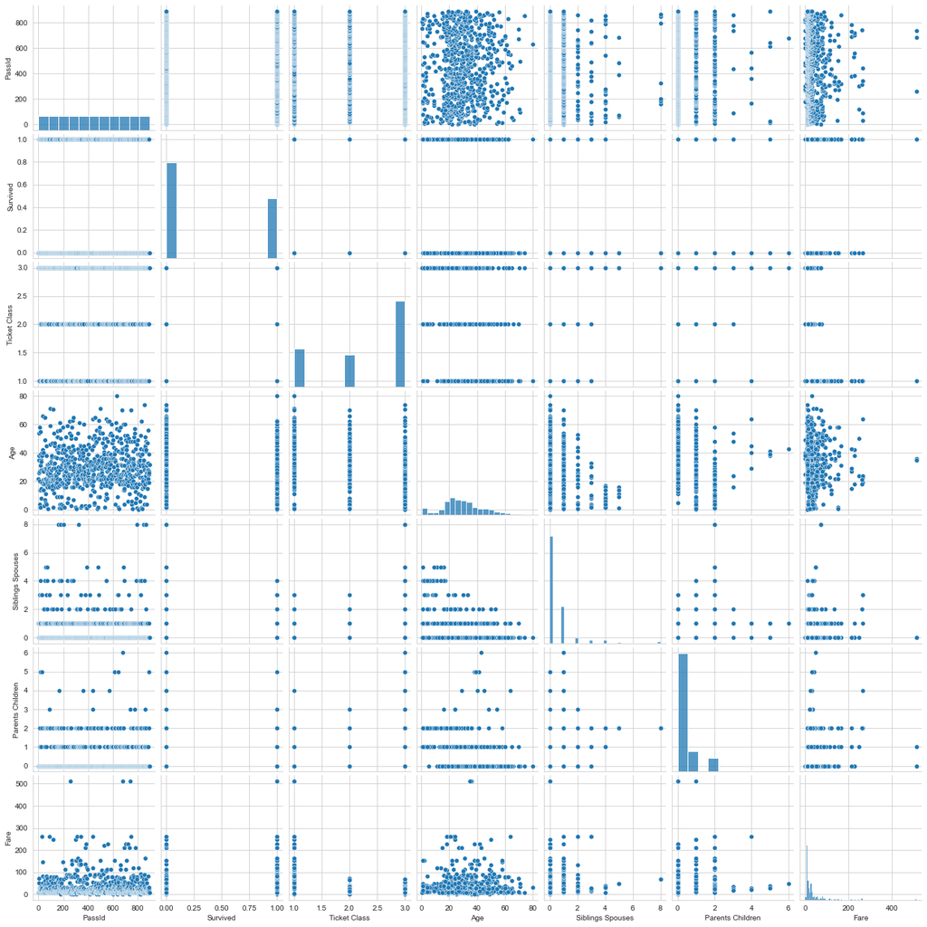

```python
sb.pairplot(train_set)

# All variables plotted against each other
```

We can see through the correlation coefficient that Sibling Spouse and Age have one of the highest correlations relative to other variables and Age.

We can see through the pairplot that Sibling Spouse and Age have data that is leaning one direction.

Now, we will show a boxplot to see if we have enough of a trend to fill in the missing Age values using the average Age value by Sibling Spouse grouping.

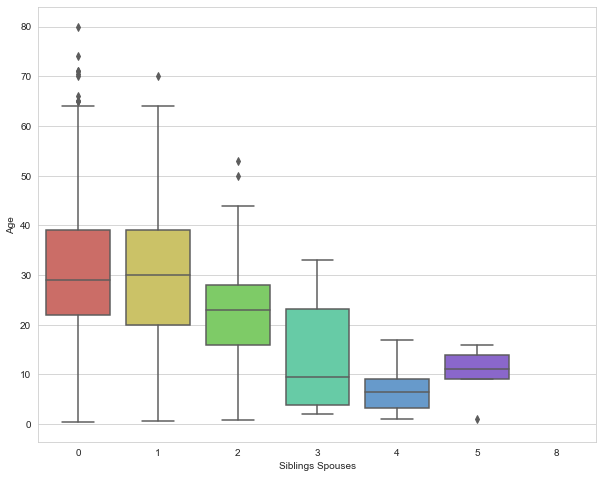

```python
sb.boxplot(x='Siblings Spouses', y='Age', data=train_set, palette='hls')
```

We can see a clear downward trend in the boxplot. We must now get the average Age per Sibling Spouse grouping.

```python
SibSpouse = train_set.groupby(train_set['Siblings Spouses'])
SibSpouse.mean()
```

| Siblings Spouses | PassId | Survived | Ticket Class | Age | Parents Children | Fare |
| --- | --- | --- | --- | --- | --- | --- |
| 0 | 455.370066 | 0.345395 | 2.351974 | 31.397558 | 0.185855 | 25.692028 |
| 1 | 439.727273 | 0.535885 | 2.057416 | 30.089727 | 0.655502 | 44.147370 |
| 2 | 412.428571 | 0.464286 | 2.357143 | 22.620000 | 0.642857 | 51.753718 |
| 3 | 321.562500 | 0.250000 | 2.562500 | 13.916667 | 1.312500 | 68.908862 |
| 4 | 381.611111 | 0.166667 | 3.000000 | 7.055556 | 1.500000 | 31.855556 |
| 5 | 336.800000 | 0.000000 | 3.000000 | 10.200000 | 2.000000 | 46.900000 |
| 8 | 481.714286 | 0.000000 | 3.000000 | NaN | 2.000000 | 69.550000 |

We can see the Average Age for Sibling Spouse 8 is NaN. We must fix this.

```python
Sib_Spouse_8 = train_set[train_set['Siblings Spouses'] == 8]
Sib_Spouse_8

# Shows all rows of data where Siblings Spouse = 8
```

|  | PassId | Survived | Ticket Class | Gender | Age | Siblings Spouses | Parents Children | Fare | Port Embarked |
| --- | --- | --- | --- | --- | --- | --- | --- | --- | --- |
| 159 | 160 | 0 | 3 | male | NaN | 8 | 2 | 69.55 | S |
| 180 | 181 | 0 | 3 | female | NaN | 8 | 2 | 69.55 | S |
| 201 | 202 | 0 | 3 | male | NaN | 8 | 2 | 69.55 | S |
| 324 | 325 | 0 | 3 | male | NaN | 8 | 2 | 69.55 | S |
| 792 | 793 | 0 | 3 | female | NaN | 8 | 2 | 69.55 | S |
| 846 | 847 | 0 | 3 | male | NaN | 8 | 2 | 69.55 | S |
| 863 | 864 | 0 | 3 | female | NaN | 8 | 2 | 69.55 | S |

Sibling Spouse Age has data points with all similar characteristics. We can find the average age for each of these statistics and average these values out to use for our average age for Siblings Spouses = 8.

```python
Ticket_Class_3 = train_set[train_set['Ticket Class'] == 3]
Ticket_Class_3.describe()
```

|  | PassId | Survived | Ticket Class | Age | Siblings Spouses | Parents Children | Fare |
| --- | --- | --- | --- | --- | --- | --- | --- |
| count | 491.000000 | 491.000000 | 491.0 | 355.000000 | 491.000000 | 491.000000 | 491.000000 |
| mean | 439.154786 | 0.242363 | 3.0 | 25.140620 | 0.615071 | 0.393075 | 13.675550 |
| std | 264.441453 | 0.428949 | 0.0 | 12.495398 | 1.374883 | 0.888861 | 11.778142 |
| min | 1.000000 | 0.000000 | 3.0 | 0.420000 | 0.000000 | 0.000000 | 0.000000 |
| 25% | 200.000000 | 0.000000 | 3.0 | 18.000000 | 0.000000 | 0.000000 | 7.750000 |
| 50% | 432.000000 | 0.000000 | 3.0 | 24.000000 | 0.000000 | 0.000000 | 8.050000 |
| 75% | 666.500000 | 0.000000 | 3.0 | 32.000000 | 1.000000 | 0.000000 | 15.500000 |
| max | 891.000000 | 1.000000 | 3.0 | 74.000000 | 8.000000 | 6.000000 | 69.550000 |

```python
Parents_Children_2 = train_set[train_set['Parents Children'] == 2]
Parents_Children_2.describe()
```

|  | PassId | Survived | Ticket Class | Age | Siblings Spouses | Parents Children | Fare |
| --- | --- | --- | --- | --- | --- | --- | --- |
| count | 80.000000 | 80.000000 | 80.000000 | 68.000000 | 80.000000 | 80.0 | 80.000000 |
| mean | 416.662500 | 0.500000 | 2.275000 | 17.216912 | 2.062500 | 2.0 | 64.337604 |
| std | 256.432237 | 0.503155 | 0.856472 | 13.193924 | 2.451265 | 0.0 | 65.993088 |
| min | 9.000000 | 0.000000 | 1.000000 | 0.830000 | 0.000000 | 2.0 | 7.750000 |
| 25% | 182.500000 | 0.000000 | 1.000000 | 5.750000 | 0.000000 | 2.0 | 26.000000 |
| 50% | 406.500000 | 0.500000 | 3.000000 | 16.500000 | 1.000000 | 2.0 | 32.881250 |
| 75% | 610.750000 | 1.000000 | 3.000000 | 25.000000 | 4.000000 | 2.0 | 69.550000 |
| max | 889.000000 | 1.000000 | 3.000000 | 58.000000 | 8.000000 | 2.0 | 263.000000 |

```python
Fare_6955 = train_set[train_set['Fare'] == 69.55]
Fare_6955.describe()
```

|  | PassId | Survived | Ticket Class | Age | Siblings Spouses | Parents Children | Fare |
| --- | --- | --- | --- | --- | --- | --- | --- |
| count | 7.000000 | 7.0 | 7.0 | 0.0 | 7.0 | 7.0 | 7.00 |
| mean | 481.714286 | 0.0 | 3.0 | NaN | 8.0 | 2.0 | 69.55 |
| std | 334.963537 | 0.0 | 0.0 | NaN | 0.0 | 0.0 | 0.00 |
| min | 160.000000 | 0.0 | 3.0 | NaN | 8.0 | 2.0 | 69.55 |
| 25% | 191.500000 | 0.0 | 3.0 | NaN | 8.0 | 2.0 | 69.55 |
| 50% | 325.000000 | 0.0 | 3.0 | NaN | 8.0 | 2.0 | 69.55 |
| 75% | 820.000000 | 0.0 | 3.0 | NaN | 8.0 | 2.0 | 69.55 |
| max | 864.000000 | 0.0 | 3.0 | NaN | 8.0 | 2.0 | 69.55 |

```python
Port_Embarked_S = train_set[train_set['Port Embarked'] == 'S']
Port_Embarked_S.describe()
```

|  | PassId | Survived | Ticket Class | Age | Siblings Spouses | Parents Children | Fare |
| --- | --- | --- | --- | --- | --- | --- | --- |
| count | 644.000000 | 644.000000 | 644.000000 | 554.000000 | 644.000000 | 644.000000 | 644.000000 |
| mean | 449.527950 | 0.336957 | 2.350932 | 29.445397 | 0.571429 | 0.413043 | 27.079812 |
| std | 256.942044 | 0.473037 | 0.789402 | 14.143192 | 1.216600 | 0.853253 | 35.887993 |
| min | 1.000000 | 0.000000 | 1.000000 | 0.670000 | 0.000000 | 0.000000 | 0.000000 |
| 25% | 225.750000 | 0.000000 | 2.000000 | 21.000000 | 0.000000 | 0.000000 | 8.050000 |
| 50% | 447.500000 | 0.000000 | 3.000000 | 28.000000 | 0.000000 | 0.000000 | 13.000000 |
| 75% | 673.250000 | 1.000000 | 3.000000 | 38.000000 | 1.000000 | 0.000000 | 27.900000 |
| max | 889.000000 | 1.000000 | 3.000000 | 80.000000 | 8.000000 | 6.000000 | 263.000000 |

Since Fare = 69.55 does not have an average age, we will average out the other three factors only.

```python
avg = (25.14 + 17.22 + 29.44)/3
avg = round(avg, 0)
print('The average age of Sibling Spouse = 8 attributes is %0.2f' %avg, '.')
```

```
The average age of Sibling Spouse = 8 attributes is 24.00 .
```

```python
SibSpouse.mean()
```

| Siblings Spouses | PassId | Survived | Ticket Class | Age | Parents Children | Fare |
| --- | --- | --- | --- | --- | --- | --- |
| 0 | 455.370066 | 0.345395 | 2.351974 | 31.397558 | 0.185855 | 25.692028 |
| 1 | 439.727273 | 0.535885 | 2.057416 | 30.089727 | 0.655502 | 44.147370 |
| 2 | 412.428571 | 0.464286 | 2.357143 | 22.620000 | 0.642857 | 51.753718 |
| 3 | 321.562500 | 0.250000 | 2.562500 | 13.916667 | 1.312500 | 68.908862 |
| 4 | 381.611111 | 0.166667 | 3.000000 | 7.055556 | 1.500000 | 31.855556 |
| 5 | 336.800000 | 0.000000 | 3.000000 | 10.200000 | 2.000000 | 46.900000 |
| 8 | 481.714286 | 0.000000 | 3.000000 | NaN | 2.000000 | 69.550000 |

We shall now fill the missing Age values.

```python
# Create a function to input missing Age values using data above

def age_approx(cols):
    Age = cols[0]
    Sib_Spouse = cols[1]

    if pd.isnull(Age):
        if Sib_Spouse == 0:
            return 31
        elif Sib_Spouse == 1:
            return 30
        elif Sib_Spouse == 2:
            return 23
        elif Sib_Spouse == 3:
            return 14
        elif Sib_Spouse == 4:
            return 7
        elif Sib_Spouse == 5:
            return 10
        else: #covers Sibling Spouse = 8
            return 24
    else:
        return Age

train_set['Age'] = train_set[['Age', 'Siblings Spouses']].apply(age_approx, axis=1)
test_set['Age'] = test_set[['Age', 'Siblings Spouses']].apply(age_approx, axis=1)
```

```python
print(train_set.isna().sum())
print(test_set.isna().sum())
```

```
PassId              0
Survived            0
Ticket Class        0
Gender              0
Age                 0
Siblings Spouses    0
Parents Children    0
Fare                0
Port Embarked       2
dtype: int64
PassId              0
Ticket Class        0
Gender              0
Age                 0
Siblings Spouses    0
Parents Children    0
Fare                1
Port Embarked       0
dtype: int64
```

We see no more missing Age values!

Let's fill in the rest of the missing values.

```python
Null_Port = train_set[train_set['Port Embarked'].isnull()]
Null_Port
```

|  | PassId | Survived | Ticket Class | Gender | Age | Siblings Spouses | Parents Children | Fare | Port Embarked |
| --- | --- | --- | --- | --- | --- | --- | --- | --- | --- |
| 61 | 62 | 1 | 1 | female | 38.0 | 0 | 0 | 80.0 | NaN |
| 829 | 830 | 1 | 1 | female | 62.0 | 0 | 0 | 80.0 | NaN |

We notice that both null Port Embarked values have a Ticket Class of 1. Let's see which Port most Ticket Class 1 people Embarked from.

```python
pd.crosstab(train_set['Port Embarked'], train_set['Ticket Class'])
```

| Ticket Class Port Embarked | 1 | 2 | 3 |
| --- | --- | --- | --- |
| C | 85 | 17 | 66 |
| Q | 2 | 3 | 72 |
| S | 127 | 164 | 353 |

We can see that most Ticket Class of 1 embarked from Port S. Therefore, we will fill the Port Embarked as Port S.

```python
train_set['Port Embarked'].fillna(value='S', inplace=True)
```

```python
Null_Port = train_set[train_set['Port Embarked'].isnull()]
Null_Port
```

|  | PassId | Survived | Ticket Class | Gender | Age | Siblings Spouses | Parents Children | Fare | Port Embarked |
| --- | --- | --- | --- | --- | --- | --- | --- | --- | --- |

All Null values are filled for our train set!

Let's take a look at our test set now.

```python
test_set.isna().sum()
```

```
PassId              0
Ticket Class        0
Gender              0
Age                 0
Siblings Spouses    0
Parents Children    0
Fare                1
Port Embarked       0
dtype: int64
```

Let's look at the one missing row for Fare.

```python
missing_Fare = test_set[test_set.isna()['Fare'] == True]
missing_Fare
```

|  | PassId | Ticket Class | Gender | Age | Siblings Spouses | Parents Children | Fare | Port Embarked |
| --- | --- | --- | --- | --- | --- | --- | --- | --- |
| 152 | 1044 | 3 | male | 60.5 | 0 | 0 | NaN | S |

```python
test_set.describe()
```

|  | PassId | Ticket Class | Age | Siblings Spouses | Parents Children | Fare |
| --- | --- | --- | --- | --- | --- | --- |
| count | 418.000000 | 418.000000 | 418.000000 | 418.000000 | 418.000000 | 417.000000 |
| mean | 1100.500000 | 2.265550 | 30.316986 | 0.447368 | 0.392344 | 35.627188 |
| std | 120.810458 | 0.841838 | 12.656785 | 0.896760 | 0.981429 | 55.907576 |
| min | 892.000000 | 1.000000 | 0.170000 | 0.000000 | 0.000000 | 0.000000 |
| 25% | 996.250000 | 1.000000 | 23.000000 | 0.000000 | 0.000000 | 7.895800 |
| 50% | 1100.500000 | 3.000000 | 30.000000 | 0.000000 | 0.000000 | 14.454200 |
| 75% | 1204.750000 | 3.000000 | 35.750000 | 1.000000 | 0.000000 | 31.500000 |
| max | 1309.000000 | 3.000000 | 76.000000 | 8.000000 | 9.000000 | 512.329200 |

The average fare for our test set is 35.63, so let's input that for our missing Fare value.

```python
test_set['Fare'].fillna(value=35.63, inplace=True)
test_set.isna().sum()
```

```
PassId              0
Ticket Class        0
Gender              0
Age                 0
Siblings Spouses    0
Parents Children    0
Fare                0
Port Embarked       0
dtype: int64
```

All Null values are filled for our test set!

Now, let's convert our categorical variables to numeric values, meaning Gender and Port Embarked. This will assist in our analyses later.

```python
Gender_num = {'male': 0, 'female': 1}
Port_Embarked_num = {'S': 1, 'C': 2, 'Q': 3}
train_set['Gender'] = train_set['Gender'].map(Gender_num)
test_set['Gender'] = test_set['Gender'].map(Gender_num)
train_set['Port Embarked'] = train_set['Port Embarked'].map(Port_Embarked_num)
test_set['Port Embarked'] = test_set['Port Embarked'].map(Port_Embarked_num)

train_set.head()

# Converting male to 0 and female to 1 for Gender
# Converting S to 1, C to 2, and Q to 3 for Port Embarked
```

|  | PassId | Survived | Ticket Class | Gender | Age | Siblings Spouses | Parents Children | Fare | Port Embarked |
| --- | --- | --- | --- | --- | --- | --- | --- | --- | --- |
| 0 | 1 | 0 | 3 | 0 | 22.0 | 1 | 0 | 7.2500 | 1 |
| 1 | 2 | 1 | 1 | 1 | 38.0 | 1 | 0 | 71.2833 | 2 |
| 2 | 3 | 1 | 3 | 1 | 26.0 | 0 | 0 | 7.9250 | 1 |
| 3 | 4 | 1 | 1 | 1 | 35.0 | 1 | 0 | 53.1000 | 1 |
| 4 | 5 | 0 | 3 | 0 | 35.0 | 0 | 0 | 8.0500 | 1 |

```python
test_set.head()
```

|  | PassId | Ticket Class | Gender | Age | Siblings Spouses | Parents Children | Fare | Port Embarked |
| --- | --- | --- | --- | --- | --- | --- | --- | --- |
| 0 | 892 | 3 | 0 | 34.5 | 0 | 0 | 7.8292 | 3 |
| 1 | 893 | 3 | 1 | 47.0 | 1 | 0 | 7.0000 | 1 |
| 2 | 894 | 2 | 0 | 62.0 | 0 | 0 | 9.6875 | 3 |
| 3 | 895 | 3 | 0 | 27.0 | 0 | 0 | 8.6625 | 1 |
| 4 | 896 | 3 | 1 | 22.0 | 1 | 1 | 12.2875 | 1 |

## Part 3 - Data Visualizations

Let's see how each of the variables correlate with each other again, this time using a heatmap.

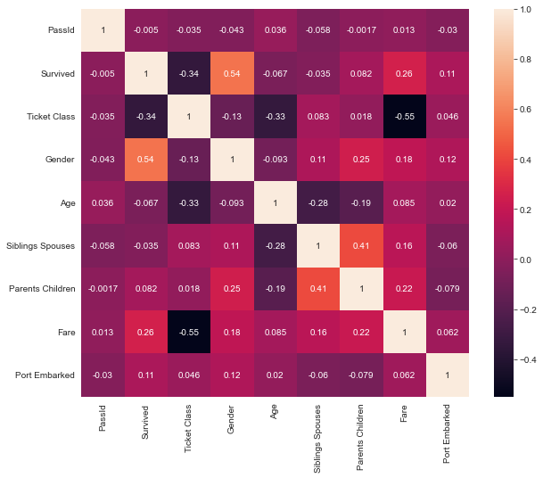

```python
sb.heatmap(train_set.corr(), square=True, annot=True)
```

```python
corr = train_set.corr()
corr
```

|  | PassId | Survived | Ticket Class | Gender | Age | Siblings Spouses | Parents Children | Fare | Port Embarked |
| --- | --- | --- | --- | --- | --- | --- | --- | --- | --- |
| PassId | 1.000000 | -0.005007 | -0.035144 | -0.042939 | 0.036322 | -0.057527 | -0.001652 | 0.012658 | -0.030467 |
| Survived | -0.005007 | 1.000000 | -0.338481 | 0.543351 | -0.067261 | -0.035322 | 0.081629 | 0.257307 | 0.106811 |
| Ticket Class | -0.035144 | -0.338481 | 1.000000 | -0.131900 | -0.333382 | 0.083081 | 0.018443 | -0.549500 | 0.045702 |
| Gender | -0.042939 | 0.543351 | -0.131900 | 1.000000 | -0.092591 | 0.114631 | 0.245489 | 0.182333 | 0.116569 |
| Age | 0.036322 | -0.067261 | -0.333382 | -0.092591 | 1.000000 | -0.276084 | -0.194844 | 0.084990 | 0.019602 |
| Siblings Spouses | -0.057527 | -0.035322 | 0.083081 | 0.114631 | -0.276084 | 1.000000 | 0.414838 | 0.159651 | -0.059961 |
| Parents Children | -0.001652 | 0.081629 | 0.018443 | 0.245489 | -0.194844 | 0.414838 | 1.000000 | 0.216225 | -0.078665 |
| Fare | 0.012658 | 0.257307 | -0.549500 | 0.182333 | 0.084990 | 0.159651 | 0.216225 | 1.000000 | 0.062142 |
| Port Embarked | -0.030467 | 0.106811 | 0.045702 | 0.116569 | 0.019602 | -0.059961 | -0.078665 | 0.062142 | 1.000000 |

Survived seems to have higher correlations with Gender and Ticket Class. Fare has a slight correlation as well.

Let's look at these visually.

```
Survived    0    1
Gender
0         468  109
1          81  233
```

[output not shown]

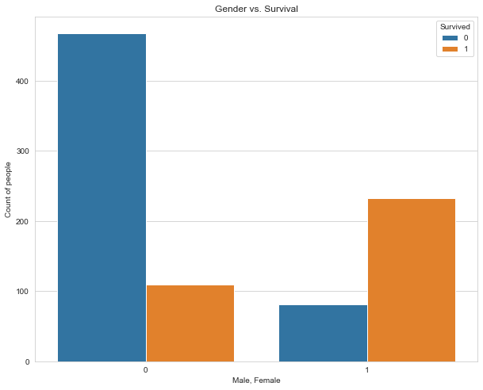

```python
print(pd.crosstab(train_set['Gender'], train_set['Survived']))
countplot = sb.countplot(x='Gender', hue='Survived', data=train_set)
countplot.set(xlabel='Male, Female', ylabel = 'Count of people', title='Gender vs. Survival')
```

```python
train_set.head()
```

|  | PassId | Survived | Ticket Class | Gender | Age | Siblings Spouses | Parents Children | Fare | Port Embarked |
| --- | --- | --- | --- | --- | --- | --- | --- | --- | --- |
| 0 | 1 | 0 | 3 | 0 | 22.0 | 1 | 0 | 7.2500 | 1 |
| 1 | 2 | 1 | 1 | 1 | 38.0 | 1 | 0 | 71.2833 | 2 |
| 2 | 3 | 1 | 3 | 1 | 26.0 | 0 | 0 | 7.9250 | 1 |
| 3 | 4 | 1 | 1 | 1 | 35.0 | 1 | 0 | 53.1000 | 1 |
| 4 | 5 | 0 | 3 | 0 | 35.0 | 0 | 0 | 8.0500 | 1 |

```python
men_survive = train_set.loc[train_set.Gender == 0]['Survived']
rate_survive_men = round((sum(men_survive)/len(men_survive))*100,2)

female_survive = train_set.loc[train_set.Gender == 1]['Survived']
rate_survive_female = round((sum(female_survive)/len(female_survive))*100,2)

print(rate_survive_men, '% of men survive.')
print(rate_survive_female, '% of women survive.')
```

```
18.89 % of men survive.
74.2 % of women survive.
```

We can see from the chart and the crosstab above that men were more likely to die, while women were more likely to survive. We can confirm that by looking at the rates of survival for men and women.

```
Survived        0    1
Ticket Class
1              80  136
2              97   87
3             372  119
```

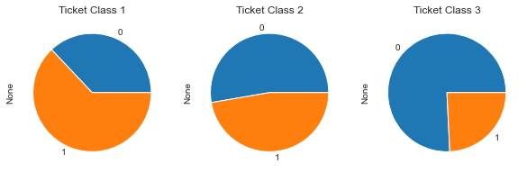

```python
print(pd.crosstab(train_set['Ticket Class'], train_set['Survived']))

figure, axes = plt.subplots(1,3)

ticket_class_1 = train_set[train_set['Ticket Class']==1]
ticket_class_2 = train_set[train_set['Ticket Class']==2]
ticket_class_3 = train_set[train_set['Ticket Class']==3]

ticket_class_1.groupby('Survived').size().plot(kind='pie', ax=axes[0], title='Ticket Class 1')
ticket_class_2.groupby('Survived').size().plot(kind='pie', ax=axes[1], title='Ticket Class 2')
ticket_class_3.groupby('Survived').size().plot(kind='pie', ax=axes[2], title='Ticket Class 3')
```

We can see that people with a lower ticket class number had a higher chance of survival.

```
               Fare
Survived
0         22.117887
1         48.395408
```

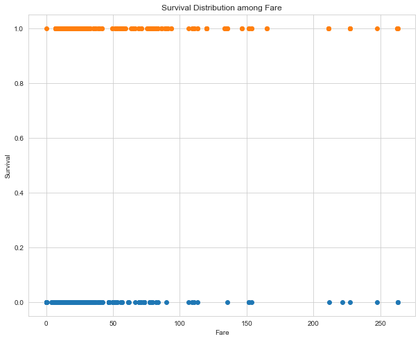

```python
print(pd.pivot_table(train_set, index = 'Survived', values = 'Fare'))

Survived_0 = train_set[train_set['Survived'] == 0]
Survived_1 = train_set[train_set['Survived'] == 1]

Survived_1_filtered = Survived_1[Survived_1['Fare'] <= 300]

plt.scatter(Survived_0['Fare'], Survived_0['Survived'])
plt.scatter(Survived_1_filtered['Fare'], Survived_1_filtered['Survived'])
plt.title('Survival Distribution among Fare')
plt.xlabel('Fare')
plt.ylabel('Survival')
plt.show()
```

As we can see, the passengers with a lower Fare were more likely to die. The graph will not clearly show this trend, as we saw earlier the correlation between Survived and Fare was not as high as other variables like Gender and Ticket Class.

I filtered out the values for more than 300 for visibility purposes. The filtered out values are analyzed below.

```python
Survived_0 = train_set[train_set['Survived'] == 0]
Survived_1 = train_set[train_set['Survived'] == 1]

Fare_high = train_set[train_set['Fare']>300]
print(Fare_high)
```

```
     PassId  Survived  Ticket Class  Gender   Age  Siblings Spouses  \
258     259         1             1       1  35.0                 0
679     680         1             1       0  36.0                 0
737     738         1             1       0  35.0                 0

     Parents Children      Fare  Port Embarked
258                 0  512.3292              2
679                 1  512.3292              2
737                 0  512.3292              2
```

We see here that the three passengers with the highest fare all had similar characteristics, with the most notable ones being they all embarked from Port 2 and they all Survived. This indicates Port Embarked 2 (C) had the three passengers with the highest ticket Fares (presumably the richest passengers?), whom all survived. All three passengers had no Siblings/Spouses on board, and all three passengers were between 35-36 years old.

## Part 4 - Outlier Analysis

Let's conduct an analysis of outliers beginning with DBScan. Let's analyze four variables -- Fare, Parents Children, Siblings Spouses, and Age.

```python
#DBSCAN

data_Fare = train_set['Fare'].values.reshape(-1,1)
model_Fare = DBSCAN(eps=0.8, min_samples=10).fit(data_Fare)
print(f'Total Fare outliers: {sum(model_Fare.labels_ == -1)}')
outliers_Fare = train_set['Fare'][model_Fare.labels_ == -1]
print(f'{outliers_Fare}\n\n')

data_Parent_Children = train_set['Parents Children'].values.reshape(-1,1)
model_Parent_Children = DBSCAN(eps=0.8, min_samples=10).fit(data_Parent_Children)
print(f'Total Parents Children outliers: {sum(model_Parent_Children.labels_ == -1)}')
outliers_Parent_Children = train_set['Parents Children'][model_Parent_Children.labels_ == -1]
print(f'{outliers_Parent_Children}\n\n')

data_Siblings_Spouses = train_set['Siblings Spouses'].values.reshape(-1,1)
model_Siblings_Spouses = DBSCAN(eps=0.8, min_samples=10).fit(data_Siblings_Spouses)
print(f'Total Siblings Spouses outliers: {sum(model_Siblings_Spouses.labels_ == -1)}')
outliers_Siblings_Spouses = train_set['Siblings Spouses'][model_Siblings_Spouses.labels_ == -1]
print(f'{outliers_Siblings_Spouses}\n\n')

data_Age = train_set['Age'].values.reshape(-1,1)
model_Age = DBSCAN(eps=0.8, min_samples=10).fit(data_Age)
print(f'Total Age outliers: {sum(model_Age.labels_ == -1)}')
outliers_Age = train_set['Age'][model_Age.labels_ == -1]
print(f'{outliers_Age}')
```

```
Total Fare outliers: 145
1       71.2833
27     263.0000
31     146.5208
34      82.1708
43      41.5792
         ...
856    164.8667
863     69.5500
867     50.4958
872      5.0000
879     83.1583
Name: Fare, Length: 145, dtype: float64


```

[output cut: 48 more lines]

We can see here that many values for Age and Fare were marked as outliers, and a few values for Parents Children and Siblings Spouses were marked as outliers.

Let's show a description of the outliers for the four variables.

```python
print('Outliers for Fare:\n\n', outliers_Fare.describe(), '\n\n')
print('Outliers for Parents Children:\n\n', outliers_Parent_Children.describe(), '\n\n')
print('Outliers for Siblings Spouses:\n\n', outliers_Siblings_Spouses.describe(), '\n\n')
print('Outliers for Age:\n\n', outliers_Age.describe())
```

```
Outliers for Fare:

 count    145.000000
mean     108.994023
std       84.538752
min        4.012500
25%       61.979200
50%       82.170800
75%      133.650000
max      512.329200
Name: Fare, dtype: float64


Outliers for Parents Children:

 count    15.000000
mean      4.133333
std       0.990430
min       3.000000
25%       3.000000
50%       4.000000
75%       5.000000
max       6.000000
Name: Parents Children, dtype: float64


Outliers for Siblings Spouses:

 count    12.000000
mean      6.750000
std       1.544786
min       5.000000
25%       5.000000
50%       8.000000
75%       8.000000
max       8.000000
Name: Siblings Spouses, dtype: float64


Outliers for Age:

 count    139.000000
mean      41.733813
std       21.773480
min        3.000000
25%       12.500000
50%       49.000000
75%       56.500000
max       80.000000
Name: Age, dtype: float64
```

Now, let's see each outliers visually.

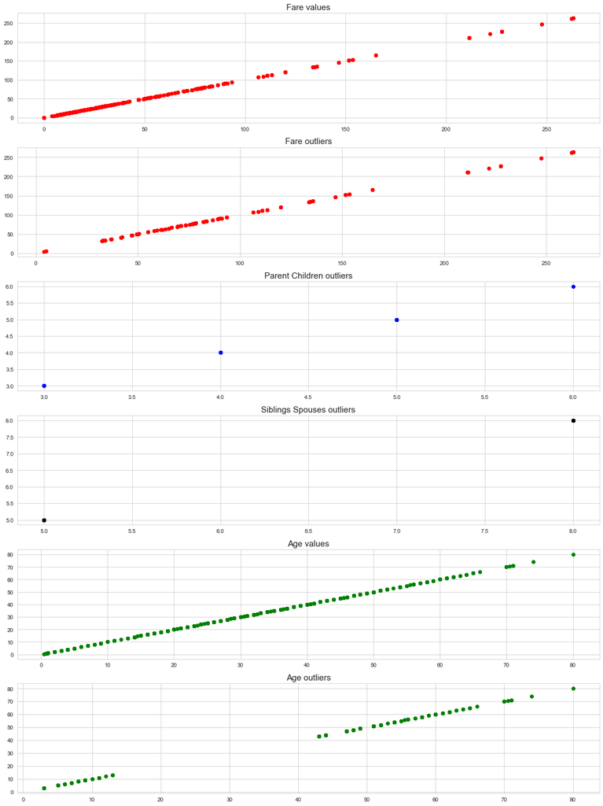

```python
fig, axes = plt.subplots(6)

fig.set_figheight(20)
fig.set_figwidth(15)

train_set_Fare_2 = train_set[train_set['Fare']<300]
outliers_Fare_2 = outliers_Fare[outliers_Fare<300.00]
axes[0].scatter(train_set_Fare_2['Fare'], train_set_Fare_2['Fare'], c='red')
axes[0].set_title('Fare values', fontsize=15)
axes[1].scatter(outliers_Fare_2, outliers_Fare_2, c='red')
axes[1].set_title('Fare outliers', fontsize=15)
axes[2].scatter(outliers_Parent_Children, outliers_Parent_Children, c='blue')
axes[2].set_title('Parent Children outliers', fontsize=15)
axes[3].scatter(outliers_Siblings_Spouses, outliers_Siblings_Spouses, c='black')
axes[3].set_title('Siblings Spouses outliers', fontsize=15)
axes[4].scatter(train_set['Age'], train_set['Age'], c='green')
axes[4].set_title('Age values', fontsize=15)
axes[5].scatter(outliers_Age, outliers_Age, c='green')
axes[5].set_title('Age outliers', fontsize=15)

fig.tight_layout()
plt.show()
```

Parents Children outliers (in blue) contain values of 3 and above, and Siblings Spouses outliers (in black) contain values of 5 and above. These are easy to see visually; however, for Fare and Age (in red and green, respectively), the outliers occur in the beginning and end of the datasets.

Let's take a deeper dive into these two variables' outliers.

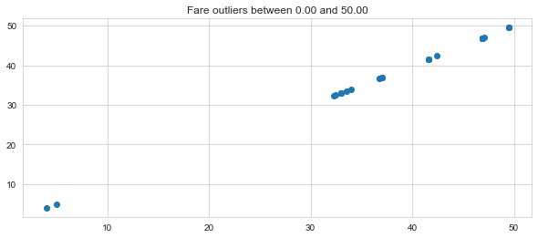

```python
outliers_Fare_2 = outliers_Fare[(outliers_Fare<50.00) & (outliers_Fare>0.00)]

plt.figure(figsize=(10,4))
plt.scatter(outliers_Fare_2, outliers_Fare_2)
plt.title('Fare outliers between 0.00 and 50.00', fontsize=12)
plt.show()
```

We can see the outliers for Fare occur before 10.00 and after 30.00. But what are the exact values before which and after which outliers occur?

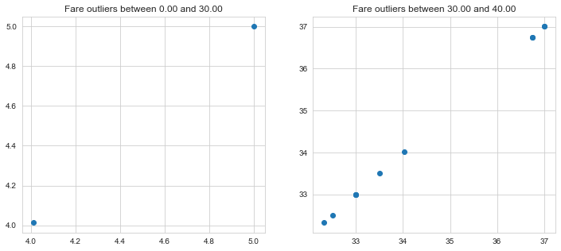

```python
fig, axes = plt.subplots(1,2)

fig.set_figheight(5)
fig.set_figwidth(12)

outliers_Fare_2 = outliers_Fare[(outliers_Fare<30.00) & (outliers_Fare>0.00)]
outliers_Fare_3 = outliers_Fare[(outliers_Fare<40.00) & (outliers_Fare>30.00)]

axes[0].scatter(outliers_Fare_2, outliers_Fare_2)
axes[0].set_title('Fare outliers between 0.00 and 30.00', fontsize=12)
axes[1].scatter(outliers_Fare_3, outliers_Fare_3)
axes[1].set_title('Fare outliers between 30.00 and 40.00', fontsize=12)
plt.show()
```

We've narrowed the maximum lower bound and minimum upper bound outlier values down to around 5.0 and 32.0, respectively. Let us get the exact Fare values from the data.

```python
print(train_set[(train_set['Fare']>=4.80) & (train_set['Fare']<=5.20)])
print('\n')
print(train_set[(train_set['Fare']<=32.4) & (train_set['Fare']>=32.00)])
```

```
     PassId  Survived  Ticket Class  Gender   Age  Siblings Spouses  \
872     873         0             1       0  33.0                 0

     Parents Children  Fare  Port Embarked
872                 0   5.0              1


     PassId  Survived  Ticket Class  Gender   Age  Siblings Spouses  \
625     626         0             1       0  61.0                 0

     Parents Children     Fare  Port Embarked
625                 0  32.3208              1
```

As we can see, the specific Fare outlier values used for bounds are 5.0 and 32.3208.

To conclude, DBScan identifies some Fare values less than or equal to 5.0 and some Fare values greater than or equal to 32.3208 as potential outliers.

Why do I say some Fare values, and not all Fare values? DBScan only identifies some of these Fare values as potential outliers, not all Fare values that fit the bounds criteria. We can confirm this below, as there are 228 Fare values of either 5.0 or under, or 32.3208 or above. However, DBScan only identified 145 of these values as potential outliers.

```python
print('Total outliers for Fare:', outliers_Fare.count(), '\n')
print('Total Fare values less than or equal to 5.0 or greater than or equal to 32.3208:', train_set[(train_set['Fare']<=5.0) | (train_set['Fare']>=32.3208)]['Fare'].count())
```

```
Total outliers for Fare: 145

Total Fare values less than or equal to 5.0 or greater than or equal to 32.3208: 228
```

Now, let's look at Age.

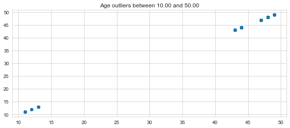

```python
outliers_Age_2 = outliers_Age[(outliers_Age<50.00) & (outliers_Age>10.00)]

plt.figure(figsize=(10,4))
plt.scatter(outliers_Age_2, outliers_Age_2)
plt.title('Age outliers between 10.00 and 50.00', fontsize=12)
plt.show()
```

We can see the outliers for Age occur before 15 and after 40. But what are the exact values before which and after which outliers occur?

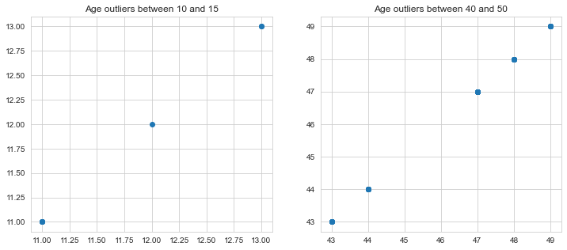

```python
fig, axes = plt.subplots(1,2)

fig.set_figheight(5)
fig.set_figwidth(12)

outliers_Age_2 = outliers_Age[(outliers_Age<15.00) & (outliers_Age>10.00)]
outliers_Age_3 = outliers_Age[(outliers_Age<50.00) & (outliers_Age>40.00)]

axes[0].scatter(outliers_Age_2, outliers_Age_2)
axes[0].set_title('Age outliers between 10 and 15', fontsize=12)
axes[1].scatter(outliers_Age_3, outliers_Age_3)
axes[1].set_title('Age outliers between 40 and 50', fontsize=12)
plt.show()
```

To conclude, DBScan identifies some Age values less than or equal to 13 and some Age values greater than or equal to 43 as potential outliers.

Similar to the Fare outliers, DBScan only identifies some of these Age values as potential outliers, not all Age values that fit the bounds criteria. We can confirm this below, as there are 200 Age values of either 13 or under, or 43 or above. However, DBScan only identified 139 of these values as potential outliers.

```python
print('Total outliers for Age:', outliers_Age.count(), '\n')
print('Total Age values less than or equal to 13 or greater than or equal to 43:', train_set[(train_set['Age']<=13) | (train_set['Age']>=43)]['Age'].count())
```

```
Total outliers for Age: 139

Total Age values less than or equal to 13 or greater than or equal to 43: 200
```

Let's try another form of outlier analysis, using Boxplots from Seaborn.

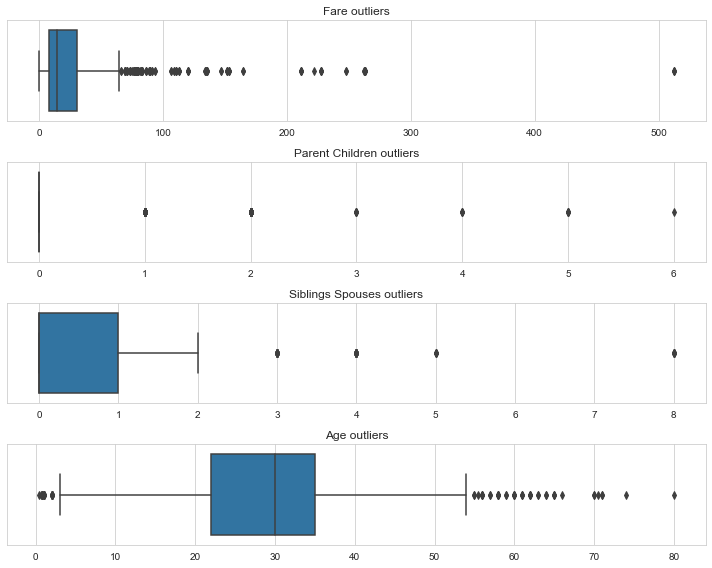

```python
fig, axes = plt.subplots(4)

sb.boxplot(train_set['Fare'], ax=axes[0]).set(title='Fare outliers', xlabel='')
sb.boxplot(train_set['Parents Children'], ax=axes[1]).set(title='Parent Children outliers', xlabel='')
sb.boxplot(train_set['Siblings Spouses'], ax=axes[2]).set(title='Siblings Spouses outliers', xlabel='')
sb.boxplot(train_set['Age'], ax=axes[3]).set(title='Age outliers', xlabel='')
fig.tight_layout()
```

We can see that Fare values greater than around 60, Parent Children values of 1 or greater, Sibling Spouse values of 3 or greater, and Age values less than around 4 or greater than around 53 are identified as outliers, using this Boxplot method.

This method of outlier analysis produced drastically different results than DBSCAN did. We can see how different outlier analysis methods analyze data and produce results so differently from one another.

## Part 5 - Applying Different Models to our Data

It is time to test our training data through applying various models and seeing which model is most effective in testing. The most effective model is what we will apply to our test set for the official submission.

First, we must split our training data into practice test and training sets. We will use an 80/20 split of our training data for train/test sets, respectively.

```python
train_set_2 = train_set

x_train, x_test, y_train, y_test = train_test_split(train_set_2.drop('Survived', axis=1), train_set_2['Survived'], test_size=0.2, random_state=0)
```

```python
print(x_train.shape)
print(y_train.shape)
```

```
(712, 8)
(712,)
```

```python
x_train.head()
```

|  | PassId | Ticket Class | Gender | Age | Siblings Spouses | Parents Children | Fare | Port Embarked |
| --- | --- | --- | --- | --- | --- | --- | --- | --- |
| 140 | 141 | 3 | 1 | 31.0 | 0 | 2 | 15.2458 | 2 |
| 439 | 440 | 2 | 0 | 31.0 | 0 | 0 | 10.5000 | 1 |
| 817 | 818 | 2 | 0 | 31.0 | 1 | 1 | 37.0042 | 2 |
| 378 | 379 | 3 | 0 | 20.0 | 0 | 0 | 4.0125 | 2 |
| 491 | 492 | 3 | 0 | 21.0 | 0 | 0 | 7.2500 | 1 |

```python
y_train.head()
```

```
140    0
439    0
817    0
378    0
491    0
Name: Survived, dtype: int64
```

It is time to put our data to the test against the various models.

#### Logistic Regression

```python
LogReg = LogisticRegression(solver='liblinear')
LogReg.fit(x_train, y_train)
y_pred_Log = LogReg.predict(x_test)

print('Classification Report\n', classification_report(y_test, y_pred_Log))
print('Confusion Matrix\n', confusion_matrix(y_test, y_pred_Log))
accuracy_LogReg = round((accuracy_score(y_test, y_pred_Log)*100),4)
print('\nAccuracy Score\n', accuracy_LogReg, '%')
```

```
Classification Report
               precision    recall  f1-score   support

           0       0.84      0.85      0.84       110
           1       0.75      0.74      0.74        69

    accuracy                           0.80       179
   macro avg       0.79      0.79      0.79       179
weighted avg       0.80      0.80      0.80       179

Confusion Matrix
 [[93 17]
 [18 51]]

Accuracy Score
 80.4469 %
```

#### Naive Bayes -- Bernoulli, Multinomial, Gaussian

```python
BernNB = BernoulliNB(binarize=True)
BernNB.fit(x_train, y_train)
y_pred_BNB = BernNB.predict(x_test)

accuracy_BernNB = round((accuracy_score(y_test, y_pred_BNB)*100),4)
print('Accuracy Score\n', accuracy_BernNB, '%')
```

```
Accuracy Score
 74.3017 %
```

```python
MultiNB = MultinomialNB()
MultiNB.fit(x_train, y_train)
y_pred_MNB = MultiNB.predict(x_test)

accuracy_MultiNB = round((accuracy_score(y_test, y_pred_MNB)*100),4)
print('Accuracy Score\n', accuracy_MultiNB, '%')
```

```
Accuracy Score
 70.3911 %
```

```python
GausNB = GaussianNB()
GausNB.fit(x_train, y_train)
y_pred_GNB = GausNB.predict(x_test)

accuracy_GausNB = round((accuracy_score(y_test, y_pred_GNB)*100),4)
print('Accuracy Score\n', accuracy_GausNB, '%')
```

```
Accuracy Score
 79.3296 %
```

#### Random Forest

```python
randomForest = RandomForestClassifier()
randomForest.fit(x_train, y_train)
y_pred_RF = randomForest.predict(x_test)

accuracy_RF = round((accuracy_score(y_test, y_pred_RF)*100),4)
print('Accuracy Score\n', accuracy_RF, '%')
```

```
Accuracy Score
 83.2402 %
```

#### Perceptron

```python
perceptron = Perceptron()
perceptron.fit(x_train, y_train)
y_pred_Per = perceptron.predict(x_test)

accuracy_Per = round((accuracy_score(y_test, y_pred_Per)*100),4)
print('Accuracy Score\n', accuracy_Per, '%')
```

```
Accuracy Score
 69.2737 %
```

#### Decision Tree

```python
decisionTree = DecisionTreeClassifier()
decisionTree.fit(x_train, y_train)
y_pred_DT = decisionTree.predict(x_test)

accuracy_DT = round((accuracy_score(y_test, y_pred_DT)*100),4)
print('Accuracy Score\n', accuracy_DT, '%')
```

```
Accuracy Score
 76.5363 %
```

#### K-Nearest Neighbor

```python
KNN = neighbors.KNeighborsClassifier()
KNN.fit(x_train, y_train)
y_pred_KNN = KNN.predict(x_test)

accuracy_KNN = round((accuracy_score(y_test, y_pred_KNN)*100),4)
print('Accuracy Score\n', accuracy_KNN, '%')
```

```
Accuracy Score
 63.6872 %
```

We have ran each model against our practice test set. Let's put all the results into a DataFrame and see how the accuracy scores compare.

```python
accuracy_model = pd.DataFrame({
    'Model': ['Logistic Regression', 'Bernoulli Naive Bayes', 'Multinomial Naive Bayes', 'Gaussian Naive Bayes', 'Random Forest', 'Perceptron', 'Decision Tree', 'K-Nearest Neighbor'],
    'Score': [accuracy_LogReg, accuracy_BernNB, accuracy_MultiNB, accuracy_GausNB, accuracy_RF, accuracy_Per, accuracy_DT, accuracy_KNN]
})
accuracy_model
```

|  | Model | Score |
| --- | --- | --- |
| 0 | Logistic Regression | 80.4469 |
| 1 | Bernoulli Naive Bayes | 74.3017 |
| 2 | Multinomial Naive Bayes | 70.3911 |
| 3 | Gaussian Naive Bayes | 79.3296 |
| 4 | Random Forest | 83.2402 |
| 5 | Perceptron | 69.2737 |
| 6 | Decision Tree | 76.5363 |
| 7 | K-Nearest Neighbor | 63.6872 |

```python
# Sorting our accuracy scores from highest to lowest

accuracy_model.sort_values(by='Score', ascending=False)
```

|  | Model | Score |
| --- | --- | --- |
| 4 | Random Forest | 83.2402 |
| 0 | Logistic Regression | 80.4469 |
| 3 | Gaussian Naive Bayes | 79.3296 |
| 6 | Decision Tree | 76.5363 |
| 1 | Bernoulli Naive Bayes | 74.3017 |
| 2 | Multinomial Naive Bayes | 70.3911 |
| 5 | Perceptron | 69.2737 |
| 7 | K-Nearest Neighbor | 63.6872 |

## Part 6 - Choosing Best Model and Creating Submission File

```python
y_pred_RF_test = randomForest.predict(test_set)
y_pred_LogReg = LogReg.predict(test_set)

# Applying Random Forest and Logistic Regression to test set
```

```python
submission = pd.DataFrame({
        'PassengerID': test_set['PassId'],
        'Survived': y_pred_RF_test
    })
submission.to_csv('/Users/akshatchopra/Desktop/Python Datasets/titanic/submission_titanic_RF.csv', index=False)

submission = pd.DataFrame({
        'PassengerID': test_set['PassId'],
        'Survived': y_pred_LogReg
    })
submission.to_csv('/Users/akshatchopra/Desktop/Python Datasets/titanic/submission_titanic_LogReg.csv', index=False)

# Creating dataframe for both models and saving both in a separate CSV file
```